# Raport z pracy domowej nr 3 z TWD

Filip Szympliński

## Wstęp

Przedstawiony w poniższym raporcie eksperyment miał na celu sprawdzenie, czy praktyki w wizualizacji danych powszechnie uważane za dobrze, rzeczywiście poprawiają czytelność. Całość badania została podzielona na trzy części. Ankietowani mieli za zadanie przekazanie swoich odczuć odnośnie tego, które wartości na wykresach są większe bądź, która reprezentacja danych jest czytelniejsza.

## Część 1.

W tej części eksperymentu jeden zestaw danych został przedstawiony za pomocą trzech różnych wykresów: kołowego 3D, kołowego 2D oraz słupkowego. Ankietowani mieli za zadanie uporządkować malejąco dane dla każdej wizualizacji osobno.

Mieli do wyboru następujące możliwości:

- a) Benzyna, Olej napędowy, LPG, Etanol, CNG → poprawna
- b) LPG, Benzyna, Olej napędowy, CNG, Etanol
- c) Olej napędowy, Benzyna, LPG, Etanol, CNG
- d) Benzyna, LPG, Olej napędowy, Etanol, CNG

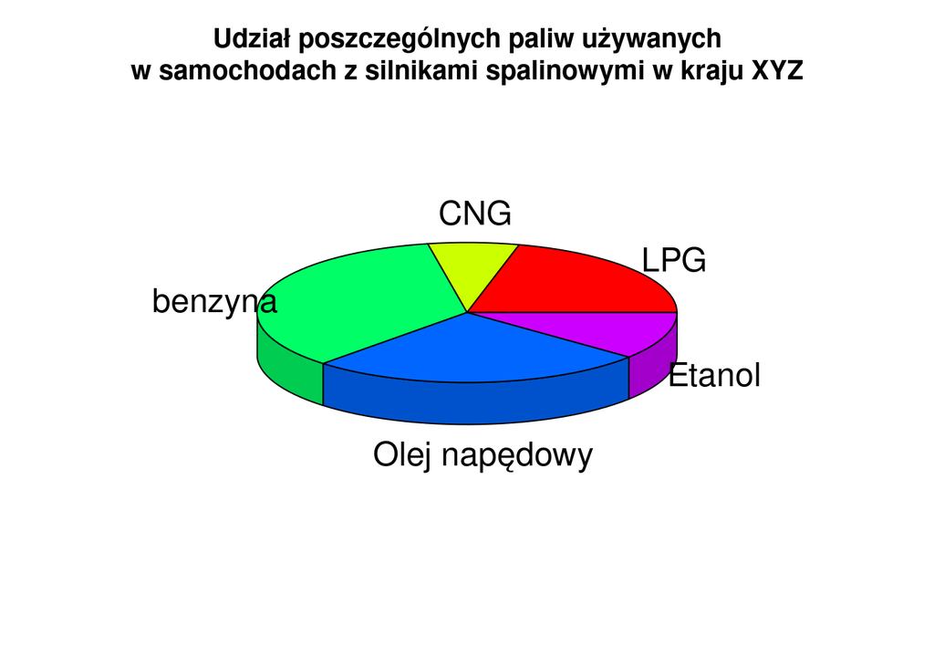

Wyniki ankietowanych dla wykresu kołowego 3D:

| Odpowiedź a) | Odpowiedź b) | Odpowiedź c) | Odpowiedź d) |
| --- | --- | --- | --- |
| 11 | 0 | 1 | 3 |

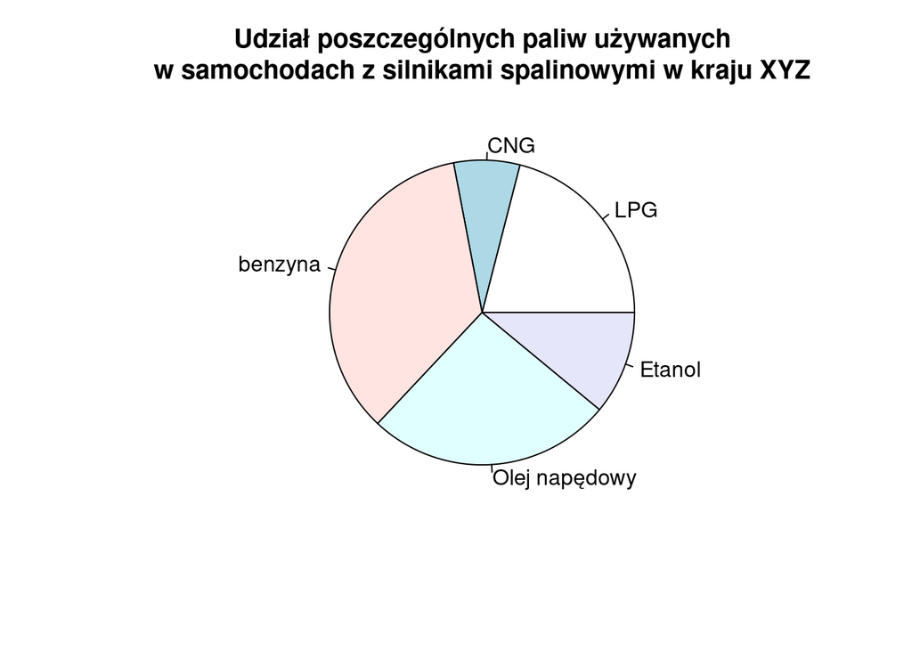

Wyniki ankietowanych dla wykresu kołowego 2D:

| Odpowiedź a) | Odpowiedź b) | Odpowiedź c) | Odpowiedź d) |
| --- | --- | --- | --- |
| 14 | 0 | 0 | 1 |

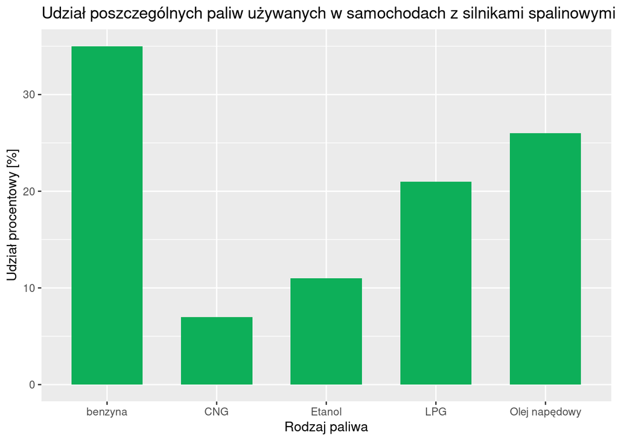

Wyniki ankietowanych dla wykresu słupkowego:

| Odpowiedź a) | Odpowiedź b) | Odpowiedź c) | Odpowiedź d) |
| --- | --- | --- | --- |
| 15 | 0 | 0 | 0 |

### Wnioski

Na podstawie uzyskanych wyników można stwierdzić, że różnice między wartościami danych najłatwiej odczytać z wykresu słupkowego. Zdecydowanie najgorzej wypadł wykres kołowy 3D. Takiego też rezultatu się można było spodziewać. Może zdziwić wynik dla drugiej wizualizacji, ale wynika to zapewne ze zbyt małej różnicy między danymi. W takim przypadku wykres kołowy 2D może mieć pewne zastosowanie, wtedy jednak najlepiej byłoby ustawić kolejne wartości malejąco.

Powyższe wnioski wydają się potwierdzać wyniki pytania o to, który wykres lepiej przedstawiał dane. 9 osób wskazało na wykres słupkowy, a 2 na kołowy 2D. 4 osoby nie udzieliły odpowiedzi na to pytanie.

## Część 2.

W następnej części eksperymentu ankietowani mieli za zadanie podanie wysokości słupka na pozycji x=0.5, y=1.0 dla wykresu poniżej.

Dostępne były następujące odpowiedzi:

- a) 3
- b) 3.5
- c) 3.25 → poprawna
- d) 2.75

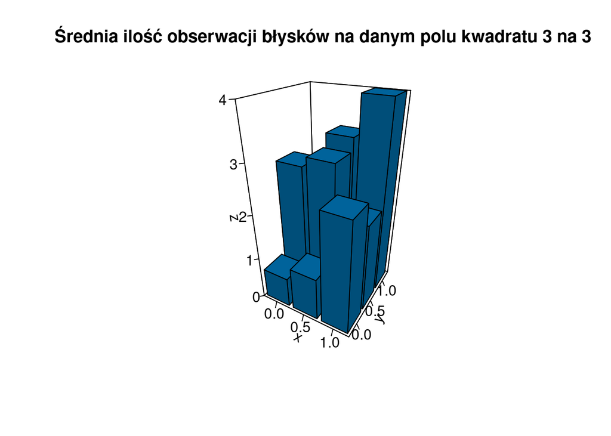

Wyniki ankietowanych:

| Odpowiedź a) | Odpowiedź b) | Odpowiedź c) | Odpowiedź d) |
| --- | --- | --- | --- |
| 3 | 1 | 11 | 0 |

### Wnioski

Z uzyskanych wyników widać, że odczytywanie wartości z wykresu słupkowego 3D sprawia pewne trudności. Ponad 25% osób niepoprawnie odczytało wysokość słupka. Obserwacja ta popiera stwierdzenie, że wykresu tego typu nie są najlepszym rozwiązaniem, bowiem jeśli obiekt jest widziany pod kątem, to nie zawsze musimy poprawnie zaobserwować jego faktyczną pozycję.

## Część 3.

W ostatniej części eksperymentu ankietowani zostali poproszeni o stwierdzenie, który z poniżej pokazanych wykresów lepiej reprezentuje dane i dlaczego.

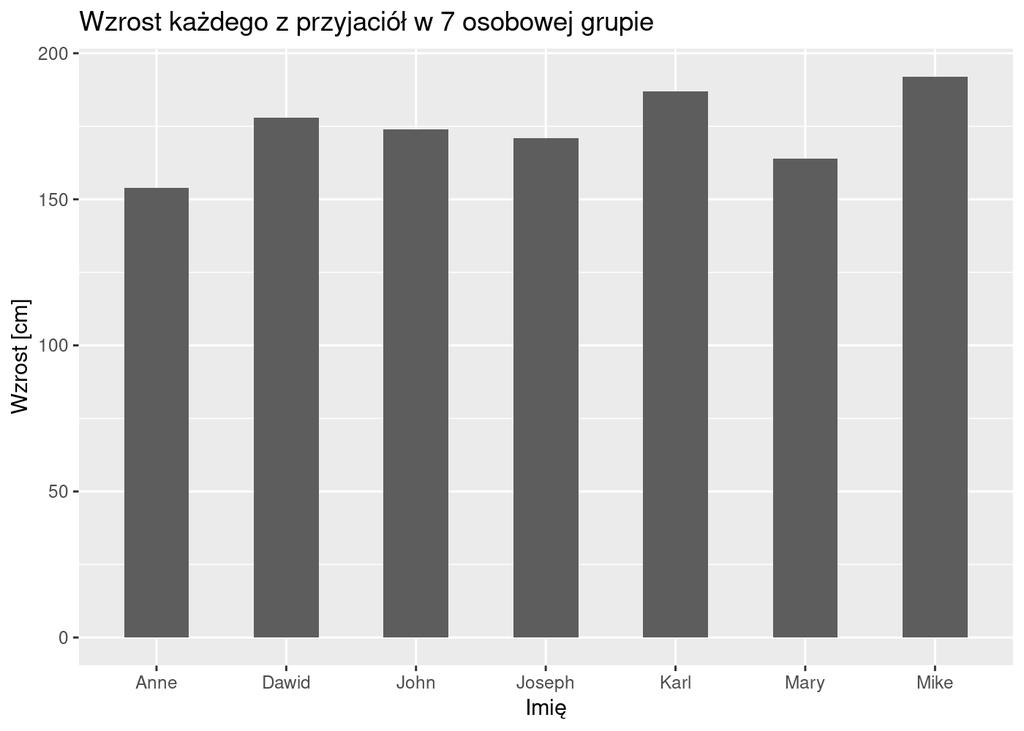

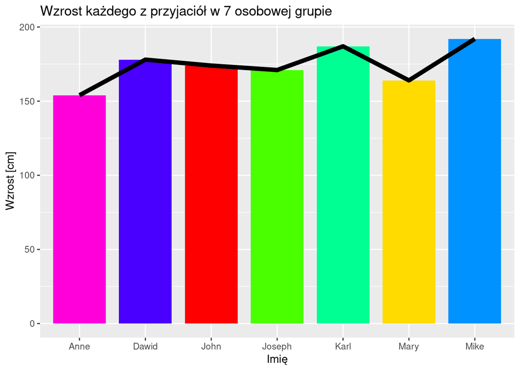

### Wyniki

Większość ankietowanych wskazała na pierwszy wykres, uważając go za bardziej przejrzysty, bez niepotrzebnych ozdobników jak np. czarna linia, które pogarszają czytelność bez wnoszenia niepotrzebnej informacji. Jednakże ciekawe jest, jak w pewnych odpowiedziach argumentowano wybór drugiego. Wskazywano między innymi na to, że linia w elegancji sposób reprezentuje różnice w wysokościach słupków, bądź że kolory pokazują, iż każda osoba jest osobną jednostką.

Podsumowując, na pierwszy wykres wskazało 11 osób, a na drugi 4.

## Wnioski z całości eksperymentu

Patrząc na wyniki z każdej części eksperymentu, można śmiało stwierdzić, że trzymanie się starych praktyk podczas tworzenia wizualizacji przynosi lepsze efekty. Nie znaczy to oczywiście, że przykładowo wykresy kołowe nie mają zastosowania. Nie jest to prawdą, jednakże należy stosować je rozważnie, bo mogą prowadzić do błędnego odczytywania danych, jak w przypadku wykresu kołowego 3D. Znacznie ma również ilość dodatkowych informacji na wizualizacji czy ozdobniki. Są one często przydatne, ale ich nadmiar może szkodzić, co zostało pokazane w 3. części.